# Cladosporium experiment 2

Devin R. Leopold

23 June, 2021

Load packages and data

```r
library(tidyverse)
library(magrittr)
library(ggtext)
library(brms)
library(bayestestR)
library(ggdist)
library(ggpubr)

#Import raw data
dat <- read.csv("data/Experiment2.csv")
dat$treatment[dat$treatment=="Pos. control"] <- "Live"

#Subset experimental treatment samples
dat.expt <- dat %>% filter(!is.na(isolate)) %>%
  mutate(plate=paste(plate,complex,sep="-"))

#Subset negative control samples
dat.neg <- dat %>% filter(is.na(isolate)) %>%
  mutate(plate=paste(plate,complex,sep="-"))
```

# Fit negative binomial mixed-model with brms.

Fixed effects in this model include the experimental treatment, the species complex of the *Cladosporium* isolates, and their interaction. Isolate identity and plate (each holding 2-3 leaf disks) and included as random intercept terms.

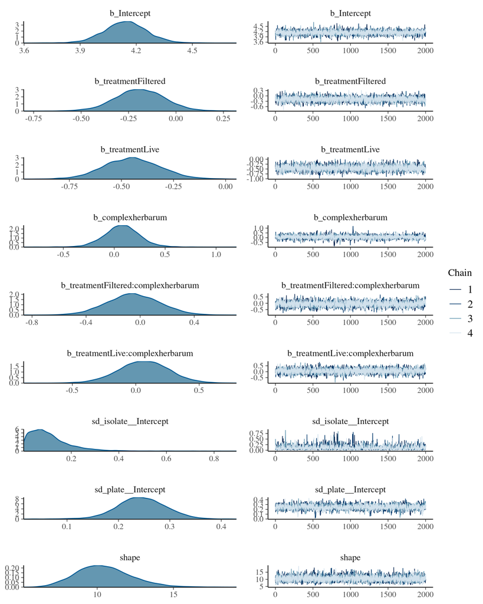

```r
model_e2 <- brm(
  disease_severity ~ treatment * complex + (1|plate) + (1|isolate),
  data = dat.expt,
  family = negbinomial(),
  chains = 4, cores = 4, iter = 4000,
  control = list(adapt_delta = 0.999),
  prior=prior(cauchy(0, 2.5), class='b'),
  sample_prior = T,
  save_pars = save_pars(all = TRUE),
  silent = 2, refresh = 0,
  seed = 80
)
plot(model_e2, N=9)
```

We can validate the model by comparing simulated data from the model to the observed data (ie posterior predictive checks).

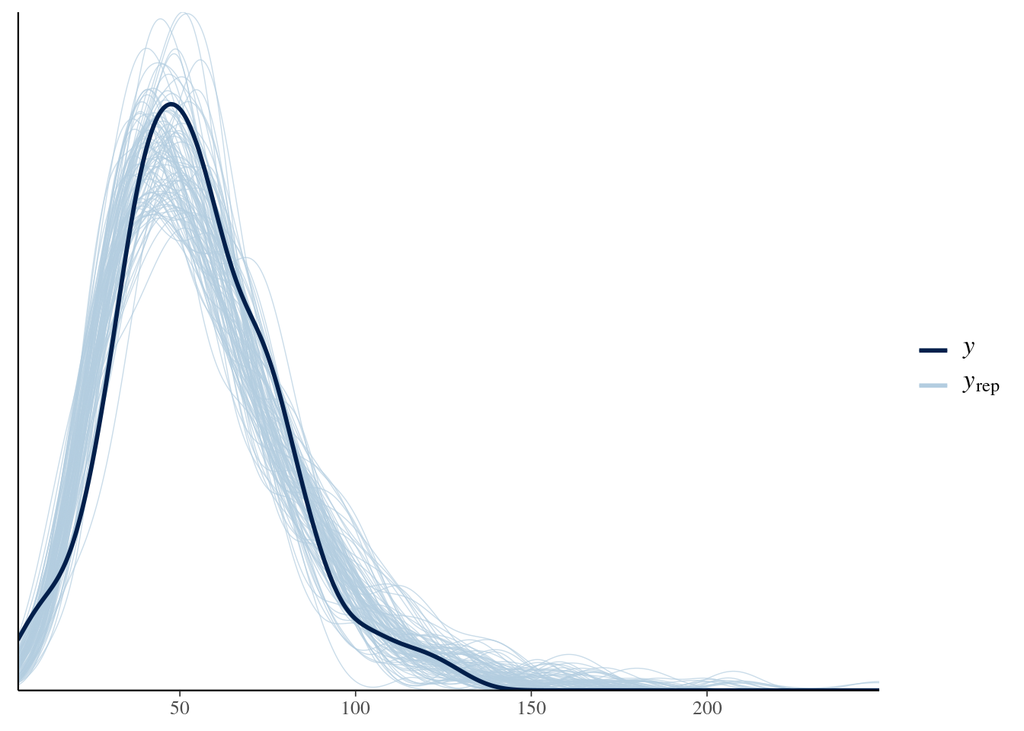

```r
pp_check(model_e2, nsamples = 100)
```

We can also check for overly influential data points using Pareto-smoothed importance sampling (PSIS).

```r
(loo_rust <- loo(model_e2, cores=parallel::detectCores(), moment_match = TRUE))
```

```
##
## Computed from 8000 by 177 log-likelihood matrix
##
##          Estimate   SE
## elpd_loo   -783.0 10.5
## p_loo        35.5  3.6
## looic      1566.1 21.1
## ------
## Monte Carlo SE of elpd_loo is 0.1.
##
## Pareto k diagnostic values:
##                          Count Pct.    Min. n_eff
## (-Inf, 0.5]   (good)     165   93.2%   1995
##  (0.5, 0.7]   (ok)        12    6.8%   278
##    (0.7, 1]   (bad)        0    0.0%   <NA>
##    (1, Inf)   (very bad)   0    0.0%   <NA>
##
## All Pareto k estimates are ok (k < 0.7).
## See help('pareto-k-diagnostic') for details.
```

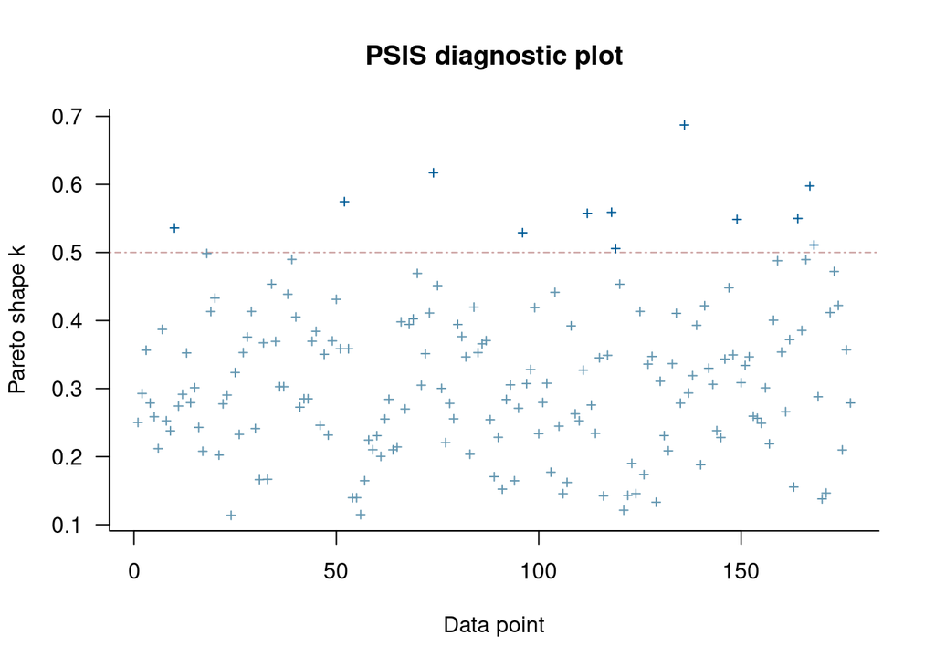

```r
plot(loo_rust)
```

# Fit negative control model

Because negative control samples do not involve any isolates, they do not fit the main model structure. In order to use these samples as a reference point we can instead fit a simple, intercept only model (with a plate-level random intercept), with an negative binomial error structure in brms. We can then use the posterior distribution and its HDI as a reference against which we can compare the other treaments

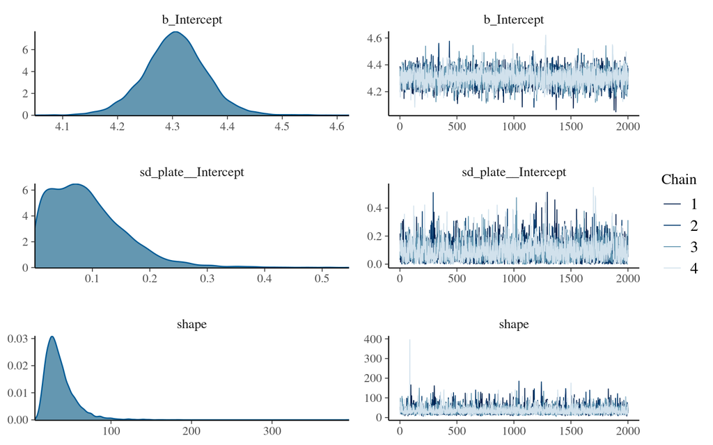

```r
model_neg <- brm(
  disease_severity ~ 1 + (1|plate),
  data = dat.neg,
  family = negbinomial(),
  chains = 4, cores = 4, iter = 4000,
  control = list(adapt_delta = 0.999),
  silent = 2, refresh = 0,
  seed = 80
)
plot(model_neg, N=3)
```

We can validate the model by comparing simulated data from the model to the observed data (ie posterior predictive checks).

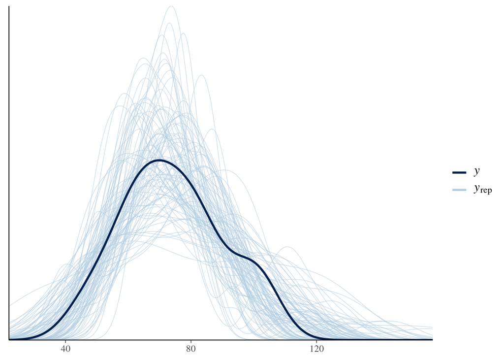

```r
pp_check(model_neg, nsamples = 100)
```

# Results

We will visualize the results by showing the posterior distribution and 89% HDIs for each treatment and species complex combination. Within each species complex we will present the probability of direction and the 89% HDI of the decrease in disease severity proceeding from Autoclaved -> Filtered -> Live *Cladosporium* inoculum. We will also overlay the median and 89% HDI of disease severity for the negative control (sterile water) samples.

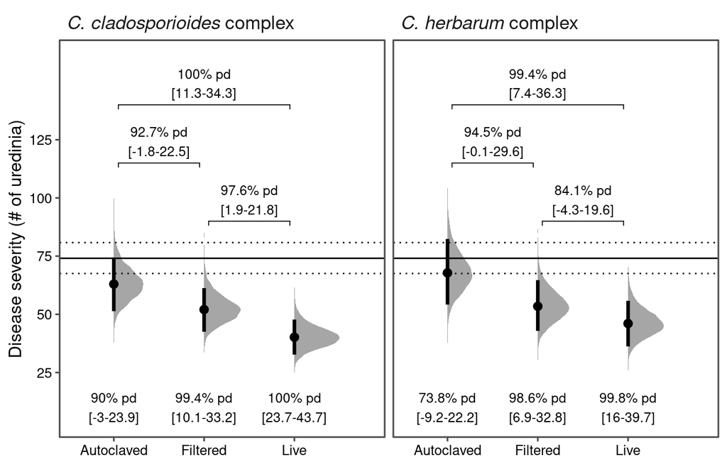